# Near-Death Experiences

## Part 3: Over-Time Analysis of “Hellish” NDEs

The analysis thus far has prompted me to consider one new question: How have “hellish” NDEs changed over time? Thanks to [Pew’s survey research](https://www.pewresearch.org/religion/2022/09/13/how-u-s-religious-composition-has-changed-in-recent-decades/), we know that the number of Americans identifying as Christian has decreased over time, and Europe has followed similar trends.

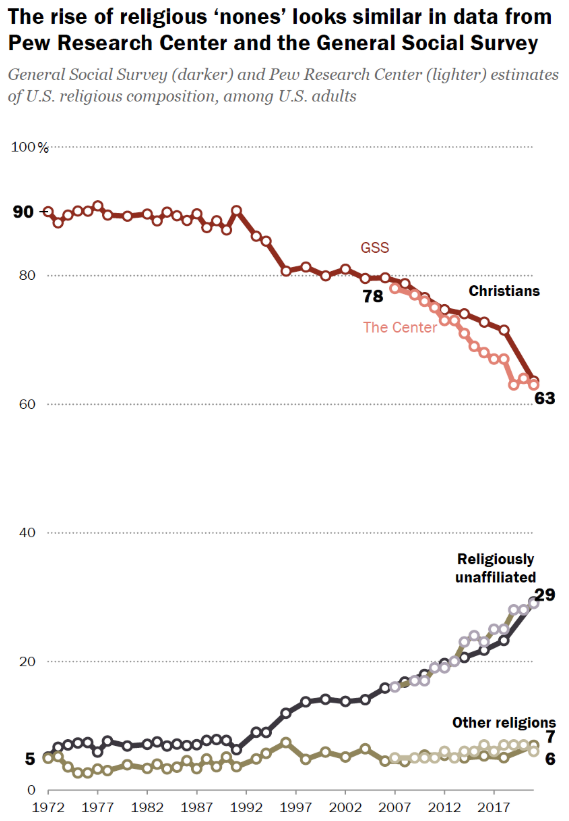

Based on these trends, I predict that hellish NDEs will have decreased over time, but let’s check in out!

```python
# extract year from date of NDE
nde_experiences['exp_date'] = pd.to_datetime(nde_experiences['exp_date'])
nde_experiences['year'] = nde_experiences['exp_date'].dt.year
```

```python
mask = nde_experiences['year'].notna()
nde_experiences_time = nde_experiences[mask]
```

```python
print(nde_experiences.shape)
print(nde_experiences_time.shape)  ## removed 76 NA values
```

```
(589, 19)
(513, 19)
```

```python
nde_experiences_time = nde_experiences_time.groupby('year').agg(
    ai_hellish_count=('ai_hellish', 'sum')
).reset_index()

nde_experiences_time.describe()
```

|  | year | ai_hellish_count |
| --- | --- | --- |
| count | 67.000000 | 67.000000 |
| mean | 1981.179104 | 0.537313 |
| std | 21.085630 | 1.004963 |
| min | 1936.000000 | 0.000000 |
| 25% | 1964.500000 | 0.000000 |
| 50% | 1981.000000 | 0.000000 |
| 75% | 1997.500000 | 1.000000 |
| max | 2024.000000 | 5.000000 |

```python
plt.figure(figsize=(10, 5))

# base scatterplot
plt.plot(nde_experiences_time['year'], nde_experiences_time['ai_hellish_count'], marker='o')

# Fit quadratic polynomial
coeffs = np.polyfit(nde_experiences_time['year'], nde_experiences_time['ai_hellish_count'], 2)
poly = np.poly1d(coeffs)

# Create smooth x values for plotting the curve
x_fit = np.linspace(nde_experiences_time['year'].min(), nde_experiences_time['year'].max(), 300)
y_fit = poly(x_fit)

# Plot quadratic fit
plt.plot(x_fit, y_fit, color='purple', linestyle='--',
         label='Quadratic fit')

plt.xlabel('Year')
plt.ylabel('Hellish Count')
plt.title('Hellish NDEs - Frequency Over Time')

plt.grid(True)
plt.tight_layout()

plt.show()
```

[figure not shown]

So this result is pretty weird and unexpected! Hellish NDEs do not appear to consistently increase or decrease, though there is a surprising cluster of hellish NDEs around the year 2000. Adding a quadratic model line indicates a gradual increase over time of hellish NDEs, though with diminishing returns.

I want to double check that the surprising peaks in the graph above are not due to there simply being more data for certain years, so I will now normalize the yearly counts (as I did with the previous analyses) and re-plot.

```python
# normalize the data because some years just have more entries than others
normalization_vector = nde_experiences['year'].value_counts().sort_index().to_numpy()
print(normalization_vector)
```

```
[ 1  1  1  2  1  2  2  4  1  4  3  1  2  3  6  4  5  4  2  7  7  7  6  7
 11  6 15  8  9 11  9 12 12 16  6  9  7  9  7 10  9 10 19 12 14  5 11 14
 14 21 20 14 16 23 23 16 15  2  1  4  2  1  1  1  2  1  2]
```

```python
# normalize the data because some years just have more entries than others
nde_experiences_time['ai_hellish_prop'] = nde_experiences_time['ai_hellish_count'] / normalization_vector
```

```python
plt.figure(figsize=(10, 5))

# base scatterplot
plt.plot(nde_experiences_time['year'], nde_experiences_time['ai_hellish_prop'], marker='o')

# Fit quadratic polynomial
coeffs = np.polyfit(nde_experiences_time['year'], nde_experiences_time['ai_hellish_prop'], 2)
poly = np.poly1d(coeffs)

# Create smooth x values for plotting the curve
x_fit = np.linspace(nde_experiences_time['year'].min(), nde_experiences_time['year'].max(), 300)
y_fit = poly(x_fit)

# Plot quadratic fit
plt.plot(x_fit, y_fit, color='purple', linestyle='--',
         label='Quadratic fit')

plt.xlabel('Year')
plt.ylabel('Hellish Proportion')
plt.title('Hellish NDEs - Proportion Over Time')

plt.grid(True)
plt.tight_layout()

plt.show()
```

[figure not shown]

This final graph does indeed show that the peaks around the year 2000 had less to do with there being more hellish NDEs and more to do with there being more NDEs in general. Adding the quadratic model line indicates a steady increase in hellish NDEs over time, solidly contradicting my previous prediction!

## Conclusion

That being said, I did discover that, contrary to my expectations, hellish NDEs have increased over time! This is a big surprising given the decline in religiosity over time, so further investigation of (a) what exactly comprisises a “hellish” NDE and (b) why these types of experiences are on the rise is certainly warranted.